# Data Analysis 1

## Draw a facet graph

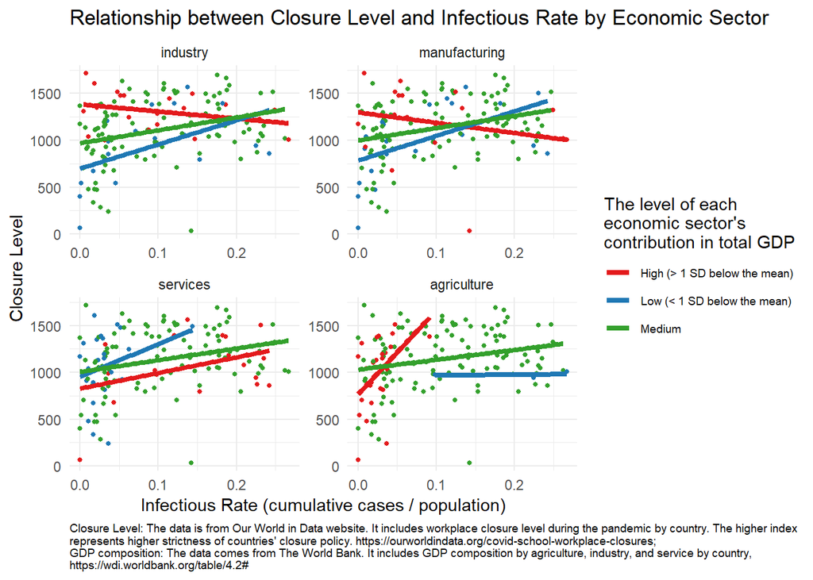

```r
# Compute mean and standard deviation for each sector
mean_industry <- mean(d_f$industry, na.rm = TRUE)
std_dev_industry <- sd(d_f$industry, na.rm = TRUE)
mean_manufacturing <- mean(d_f$manufacturing, na.rm = TRUE)
std_dev_manufacturing <- sd(d_f$manufacturing, na.rm = TRUE)
mean_services <- mean(d_f$services, na.rm = TRUE)
std_dev_services <- sd(d_f$services, na.rm = TRUE)
mean_agriculture <- mean(d_f$agriculture, na.rm = TRUE)
std_dev_agriculture <- sd(d_f$agriculture, na.rm = TRUE)

# Create a new column for each sector group
d_new <- d_f %>%
  mutate(
    industry = case_when(
      industry < mean_industry - std_dev_industry ~ "Low (< 1 SD below the mean)",
      industry > mean_industry + std_dev_industry ~ "High (> 1 SD below the mean)",
      TRUE ~ "Medium"
    ),
    manufacturing = case_when(
      manufacturing < mean_manufacturing - std_dev_manufacturing ~ "Low (< 1 SD below the mean)",
      manufacturing > mean_manufacturing + std_dev_manufacturing ~ "High (> 1 SD below the mean)",
      TRUE ~ "Medium"
    ),
    services = case_when(
      services < mean_services - std_dev_services ~ "Low (< 1 SD below the mean)",
      services > mean_services + std_dev_services ~ "High (> 1 SD below the mean)",
      TRUE ~ "Medium"
    ),
    agriculture = case_when(
      agriculture < mean_agriculture - std_dev_agriculture ~ "Low (< 1 SD below the mean)",
      agriculture > mean_agriculture + std_dev_agriculture ~ "High (> 1 SD below the mean)",
      TRUE ~ "Medium"
    )
  )

# Combine the four groups into a single column for facetting
d_long <- d_new %>%
  gather(key = "sector_group", value = "group", industry, manufacturing, services, agriculture)

# Create the plot
d_long$sector_group <- factor(d_long$sector_group, levels = c("industry", "manufacturing", "services", "agriculture"))

ggplot(d_long, aes(x = infectious_rate_t, y = closure, color = group)) +
  geom_point(size = 1) +
  geom_smooth(method = "lm", se = FALSE, size = 1.5) +
  theme_minimal() +
  labs(title = "Relationship between Closure Level and Infectious Rate by Economic Sector",
       x = "Infectious Rate (cumulative cases / population)",
       y = "Closure Level",
       color = "The level of each\neconomic sector's\ncontribution in total GDP") +
  facet_wrap(~ sector_group, scales = "free", ncol = 2) +
  scale_color_manual(values = c("Low (< 1 SD below the mean)" = "#1f78b4",
                                "Medium" = "#33a02c",
                                "High (> 1 SD below the mean)" = "#e31a1c")) +
  theme(legend.text = element_text(size = 7),
        plot.caption = element_text(hjust = 0, size = 7)) +
  labs(caption = "Closure Level: The data is from Our World in Data website. It includes workplace closure level during the pandemic by country. The higher index\nrepresents higher strictness of countries' closure policy. https://ourworldindata.org/covid-school-workplace-closures;\nGDP composition: The data comes from The World Bank. It includes GDP composition by agriculture, industry, and service by country,\nhttps://wdi.worldbank.org/table/4.2#")
```

The hypothesis is confirmed. Agriculture and services may not be as severely influenced by workplace closure as industry. Service-based economies might have greater flexibility to adapt to closures, as more jobs in this sector can transition to remote work. This can influence the extent and stringency of workplace closure policies.

# Model Analysis 3

## Analysing Hypothesized Model

Does industrial sector’s share of GDP interact with export volume to have effects on workplace closure policy?

```r
mod_2 <- lm(closure ~ sum_ex*industry, data = d_f)
summary(mod_2)
```

```
##
## Call:
## lm(formula = closure ~ sum_ex * industry, data = d_f)
##
## Residuals:
##      Min       1Q   Median       3Q      Max
## -1130.16  -185.94    16.29   223.59   591.90
##
## Coefficients:
##                   Estimate Std. Error t value Pr(>|t|)
## (Intercept)      8.583e+02  8.245e+01  10.409  < 2e-16 ***
## sum_ex           3.214e-04  3.417e-04   0.941  0.34852
## industry         9.451e+00  3.086e+00   3.062  0.00263 **
## sum_ex:industry -1.098e-06  1.306e-05  -0.084  0.93312
## ---
## Signif. codes:  0 '***' 0.001 '**' 0.01 '*' 0.05 '.' 0.1 ' ' 1
##
## Residual standard error: 323.3 on 142 degrees of freedom
## Multiple R-squared:  0.1063, Adjusted R-squared:  0.08741
## F-statistic: 5.629 on 3 and 142 DF,  p-value: 0.001128
```

The interaction is not significant according to the model summary, let’s test the data against General Linear Model’s assumptions:

## Categorizing Quantitative Variable And Testing Model Assumptions

Before testing model assumptions, since both variables under interaction term are quantitative, for convenience of analysis and visualization, we we group the continuous values of proportion of industrial sectors’ contribution to GDP into categories of “High”, “Low” and “Medium”, and put them back into the model:

```r
# Relevel to make 'Low' the reference group
d_f$industry_group <- relevel(d_f$industry_group, ref = "Low(> 1 sd above the mean)")
mod2_low <- lm(closure ~ sum_ex, data = d_f[d_f$industry_group == "Low(> 1 sd above the mean)", ])

# Relevel to make 'Medium' the reference group
d_f$industry_group <- relevel(d_f$industry_group, ref = "Medium")
mod2_medium <- lm(closure ~ sum_ex, data = d_f[d_f$industry_group == "Medium",])

d_f$industry_group <- relevel(d_f$industry_group, ref = "High(< 1 sd below the mean)")
mod2_high <- lm(closure ~ sum_ex, data = d_f[d_f$industry_group == "High(< 1 sd below the mean)",])
```

### Testing Against Normality Distribution of Error

test the model for data that are in “Low” industry group

```r
x2_norms1 <- modelAssumptions(mod2_low, "NORMAL")
```

```
## Descriptive Statistics for Studentized Residuals
```

test the model for data that are in “Medium” industry group

```r
x2_norms2 <- modelAssumptions(mod2_medium, "NORMAL")
```

```
## Descriptive Statistics for Studentized Residuals
```

test the model for data that are in “High” industry group

```r
x2_norms3 <- modelAssumptions(mod2_high, "NORMAL")
```

```
## Descriptive Statistics for Studentized Residuals
```

All three groups fulfill the normality distribution of error.

### Testing Against Constant Variance of Error

test the model for data that are in “Low” industry group

```r
x2_constant1 <-  modelAssumptions(mod2_low, "CONSTANT")
```

```
##
## Suggested power transformation:  -0.984788
##
##
## Non-constant Variance Score Test
## Variance formula: ~ fitted.values
## Chisquare = 0.4634117, Df = 1, p = 0.49603
```

test the model for data that are in “Medium” industry group

```r
x2_constant2 <- modelAssumptions(mod2_medium, "CONSTANT")
```

```
##
## Suggested power transformation:  8.769927
##
##
## Non-constant Variance Score Test
## Variance formula: ~ fitted.values
## Chisquare = 1.366154, Df = 1, p = 0.24247
```

test the model for data that are in “High” industry group

```r
x2_constant3 <- modelAssumptions(mod2_high, "CONSTANT")
```

```
##
## Suggested power transformation:  6.513751
##
##
## Non-constant Variance Score Test
## Variance formula: ~ fitted.values
## Chisquare = 0.4621929, Df = 1, p = 0.4966
```

### Testing Against Linearity

test the model for data that are in “Low” industry group

```r
x2_linear1 <- modelAssumptions(mod2_low, "LINEAR")
```

test the model for data that are in “Medium” industry group

```r
x2_linear2 <- modelAssumptions(mod2_medium, "LINEAR")
```

test the model for data that are in “High” industry group

```r
x2_linear3 <- modelAssumptions(mod2_high, "LINEAR")
```

## Apply Transformation to a predictor and Test the Model Assumptions

We transformed the predictor and fit it into the model

```r
d_f$sum_ex_log <- log(d_f$sum_ex + 1)
d_f$industry_group <- relevel(d_f$industry_group, ref = "Low(> 1 sd above the mean)")
mod2_tlow <- lm(closure ~ sum_ex_log, data = d_f[d_f$industry_group == "Low(> 1 sd above the mean)", ])

# Relevel to make 'Medium' the reference group
d_f$industry_group <- relevel(d_f$industry_group, ref = "Medium")
mod2_tmedium <- lm(closure ~ sum_ex_log, data = d_f[d_f$industry_group == "Medium",])

d_f$industry_group <- relevel(d_f$industry_group, ref = "High(< 1 sd below the mean)")
mod2_thigh <- lm(closure ~ sum_ex_log, data = d_f[d_f$industry_group == "High(< 1 sd below the mean)",])
```

### Testing Transformed Model Against Normality Distribution of Error

test the model for data that are in “Low” industry group

```r
x2_norms1t <- modelAssumptions(mod2_tlow, "NORMAL")
```

```
## Descriptive Statistics for Studentized Residuals
```

test the model for data that are in “Medium” industry group

```r
x2_norms2t <- modelAssumptions(mod2_tmedium, "NORMAL")
```

```
## Descriptive Statistics for Studentized Residuals
```

test the model for data that are in “High” industry group

```r
x2_norms3t <- modelAssumptions(mod2_thigh, "NORMAL")
```

```
## Descriptive Statistics for Studentized Residuals
```

All three groups still fulfill the normality distribution of error.

### Testing Transformed Model Against Constant Variance of Error

test the model for data that are in “Low” industry group

```r
x2_constant1t <-  modelAssumptions(mod2_tlow, "CONSTANT")
```

```
##
## Suggested power transformation:  0.5498111
##
##
## Non-constant Variance Score Test
## Variance formula: ~ fitted.values
## Chisquare = 0.580003, Df = 1, p = 0.44631
```

test the model for data that are in “Medium” industry group

```r
x2_constant2t <- modelAssumptions(mod2_tmedium, "CONSTANT")
```

```
##
## Suggested power transformation:  1.067279
##
##
## Non-constant Variance Score Test
## Variance formula: ~ fitted.values
## Chisquare = 0.7141659, Df = 1, p = 0.39806
```

test the model for data that are in “High” industry group

```r
x2_constant3t <- modelAssumptions(mod2_thigh, "CONSTANT")
```

```
##
## Suggested power transformation:  0.4617535
##
##
## Non-constant Variance Score Test
## Variance formula: ~ fitted.values
## Chisquare = 0.2143214, Df = 1, p = 0.6434
```

### Testing Transformed Model Against Linearity

test the model for data that are in “Low” industry group

```r
x2_linear1t <- modelAssumptions(mod2_tlow, "LINEAR")
```

test the model for data that are in “Medium” industry group

```r
x2_linear2t <- modelAssumptions(mod2_tmedium, "LINEAR")
```

test the model for data that are in “High” industry group

```r
x2_linear3t <- modelAssumptions(mod2_thigh, "LINEAR")
```

Although the “Low” group still seems to have issue with linearity, but the issue does not seem severe since there are less observation in “Low” group than “Medium” and “High” group. And after applying Model Transformation, we solved the model assumptions issues with “High” and “Medium” group. All the data are ready to be applied General Linear Analysis now.

## Analysing Model After Application of Transformation

The interaction term is not significant, it seems that our hypothesis is not confirmed

```r
mod_2t <- lm(closure ~ sum_ex_log*industry, data = d_f)
summary(mod_2t)
```

```
##
## Call:
## lm(formula = closure ~ sum_ex_log * industry, data = d_f)
##
## Residuals:
##      Min       1Q   Median       3Q      Max
## -1159.60  -183.35    42.73   220.34   623.73
##
## Coefficients:
##                     Estimate Std. Error t value Pr(>|t|)
## (Intercept)          -28.074    343.969  -0.082  0.93506
## sum_ex_log           105.199     37.894   2.776  0.00624 **
## industry              25.107     13.897   1.807  0.07294 .
## sum_ex_log:industry   -1.993      1.496  -1.332  0.18485
## ---
## Signif. codes:  0 '***' 0.001 '**' 0.01 '*' 0.05 '.' 0.1 ' ' 1
##
## Residual standard error: 308.4 on 142 degrees of freedom
## Multiple R-squared:  0.1868, Adjusted R-squared:  0.1696
## F-statistic: 10.87 on 3 and 142 DF,  p-value: 1.796e-06
```

```r
car::Anova(mod_2t, type = 3) %>% eta_squared()
```

```
## Type 3 ANOVAs only give sensible and informative results when covariates
##   are mean-centered and factors are coded with orthogonal contrasts (such
##   as those produced by `contr.sum`, `contr.poly`, or `contr.helmert`, but
##   *not* by the default `contr.treatment`).
```

```
## # Effect Size for ANOVA (Type III)
##
## Parameter           | Eta2 (partial) |       95% CI
## ---------------------------------------------------
## sum_ex_log          |           0.05 | [0.01, 1.00]
## industry            |           0.02 | [0.00, 1.00]
## sum_ex_log:industry |           0.01 | [0.00, 1.00]
##
## - One-sided CIs: upper bound fixed at [1.00].
```

### Plotting the graph

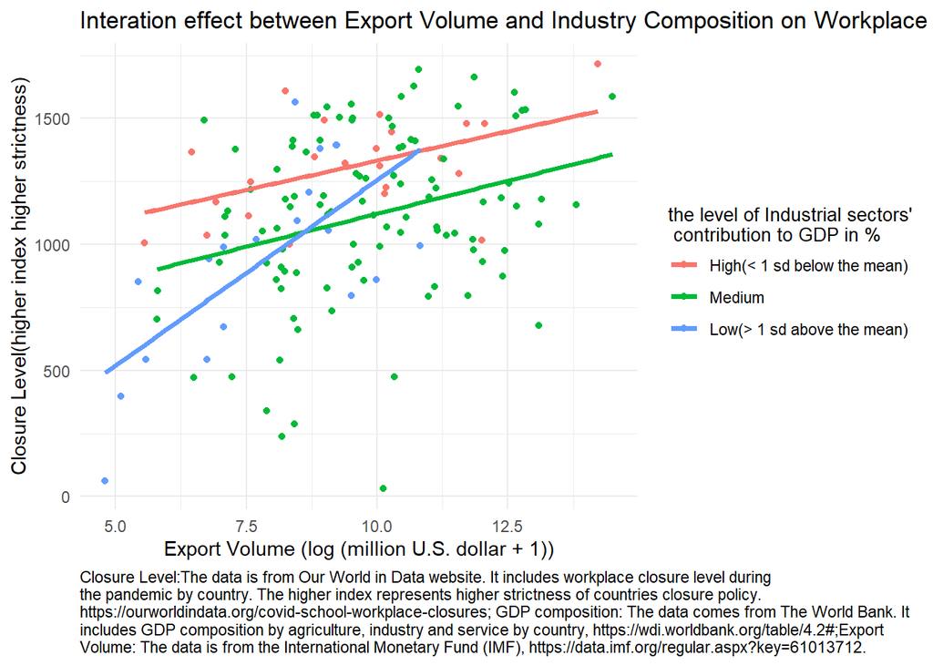

```r
ggplot(d_f, aes(x = sum_ex_log, y = closure, color = industry_group)) +
  geom_point() +
  geom_smooth(method = "lm", se = FALSE,  size = 1.3) +
  labs(x = "Export Volume (log (million U.S. dollar + 1))", y = "Closure Level(higher index higher strictness)", color = "the level of Industrial sectors'\n contribution to GDP in %", title = "Interation effect between Export Volume and Industry Composition on Workplace Closures", caption = str_wrap("Closure Level:The data is from Our World in Data website. It includes workplace closure level during the pandemic by country. The higher index represents higher strictness of countries closure policy. https://ourworldindata.org/covid-school-workplace-closures; GDP composition: The data comes from The World Bank. It includes GDP composition by agriculture, industry and service by country, https://wdi.worldbank.org/table/4.2#;Export Volume: The data is from the International Monetary Fund (IMF), https://data.imf.org/regular.aspx?key=61013712.", 120)) +
  theme_minimal() + theme(plot.title = element_text(size = 13, hjust = 0), legend.title = element_text(size = 10, margin = margin(t = -2, b = -2)), legend.box = "none",plot.caption = element_text(hjust = 0))
```

## Analysing the Outlier

```r
x2_cooks <- modelCaseAnalysis(mod_2t, Type = "COOKSD")
```

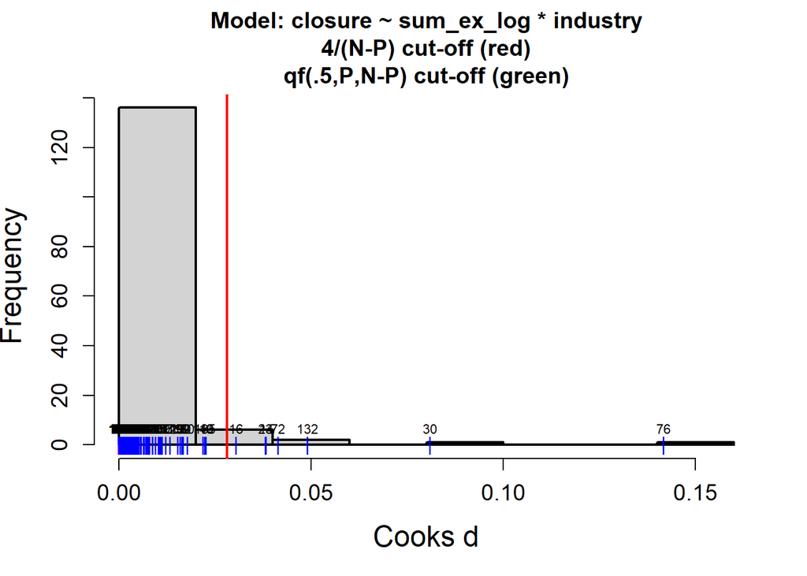

Look at the dfBetas, since the interaction is not significant, we want look into which outlier that influence specifically the interaction term the most

```r
x_infs <- modelCaseAnalysis(mod_2t, Type = "DFBETAS")
```

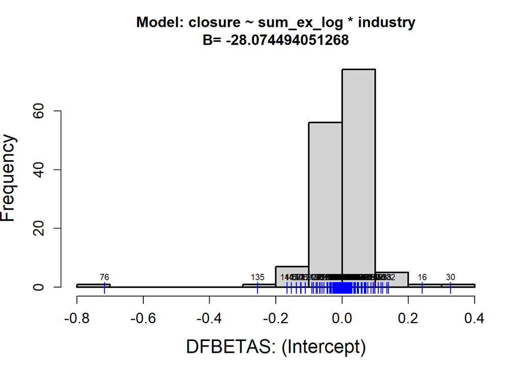

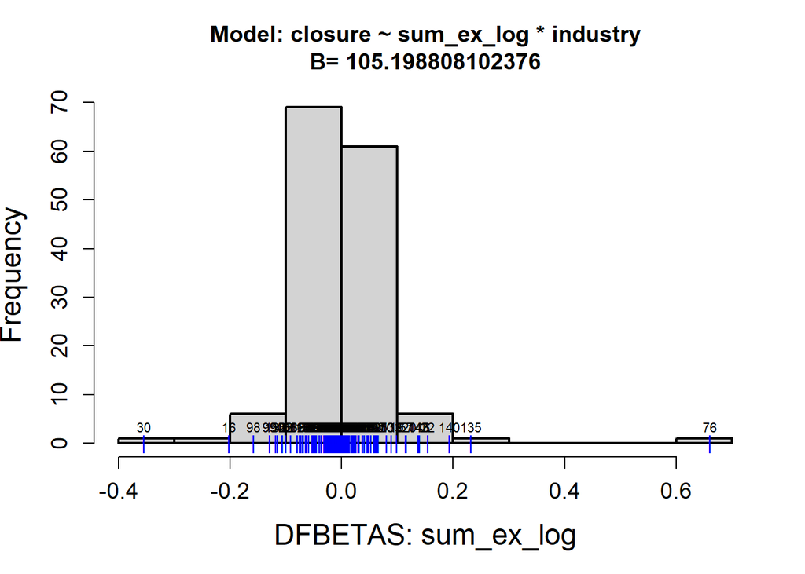

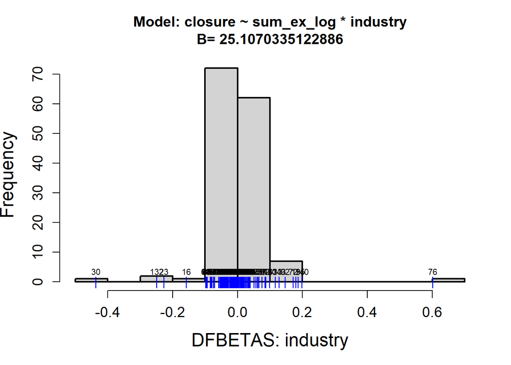

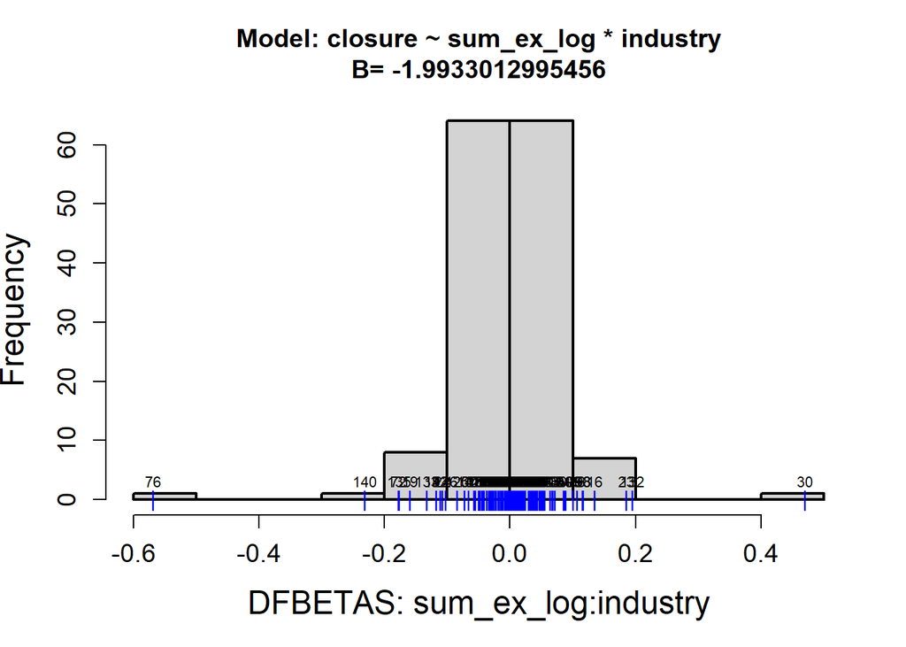

We saw that the outliers for interaction term are:

```r
d_f[c(76, 30), ]
```

```
##    unnamed_0  country closure     gdp agriculture industry manufacturing
## 76        81 Kiribati      63     0.2        26.7     10.0           4.4
## 30        31    China    1715 14687.7         7.7     37.8          26.3
##    services population yearly_change net_change density_p_km land_area_km
## 76     69.2     133515         1.74%      2,283          165          810
## 30     54.5 1425671352        -0.02%   -215,985          152      9388211
##    migrants_net fert_rate med_age urban_pop world_share      sum_im
## 76         -400       3.2      22       56%       0.00%     181.204
## 30      -310220       1.2      39       65%      17.72% 2103640.793
##          sum_ex cumulative_cases cumulative_deaths infectious_rate
## 76     120.5573                0                 0    0.000000e+00
## 30 1499086.1780            96673              4788    6.780876e-05
##    infectious_rate_t              industry_group sum_ex_log
## 76       0.000000000  Low(> 1 sd above the mean)   4.800386
## 30       0.008234607 High(< 1 sd below the mean)  14.220367
```

We need to discuss further whether removal of outliers is necessary, and how our model estimation would change after removing the outliers